# Model 3 and Data Viz

RW Hass

2024-02-20

# Random Coefficients Model (Model 3) Visualized

Understanding what random effects are (and why we care about their variance) is among the hardest components of learning multilevel modeling. However, we’re now in a position to explore the data graphically to get a sense of what we’re analyzing

This vignette makes use of some great code by [Rens van de Schoot](https://www.rensvandeschoot.com/tutorials/lme4/)

## Random Coefficients model

In the slides, we review the random coefficients model which is (for this example) a two-level model, with a predictor at level 1 (center-SES or `cses` in our data set), and the outcome also at level 1 (`mathach`).

Unlike models 1 and 2, where our focus is on level 2 units (schools) here, we’re going to delve within each school and ask about the relationship between a student’s `cses` level and that student’s `mathach` score.

### Visualizing the data

First, let’s visualize the cses - mathach relationship without respect to school.

Here’s an overall plot of all $n = 7185$ students’ cses and math achievement scores. It looks pretty incoherent. Given the known hierarchical structure of the data, this is not surprising, so we should try to understand what’s happening within each school and between schools.

However, we still see that, ignoring the clustering, there’s some degree of linear relationship between a student’s SES and his or her math achievement score.

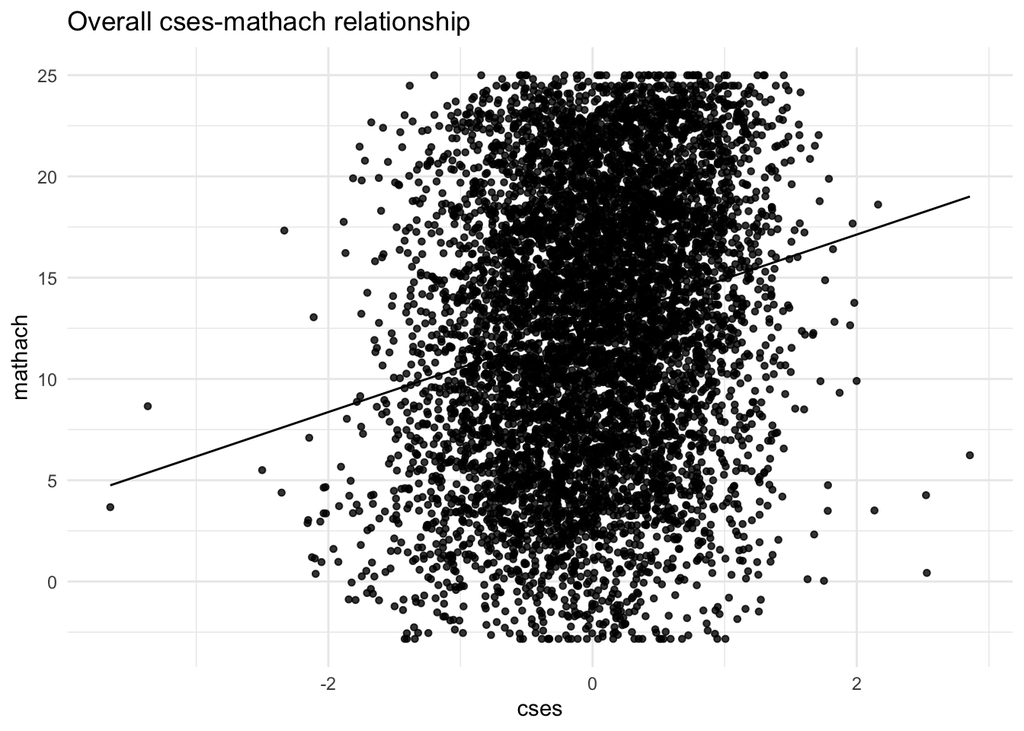

Let’s sample 50 schools (there are 160 total) and visualize the differences. We do this because it’s hard to see what’s going on across all 160.

First, let’s just look at the scatterplot with schools identified as colors.

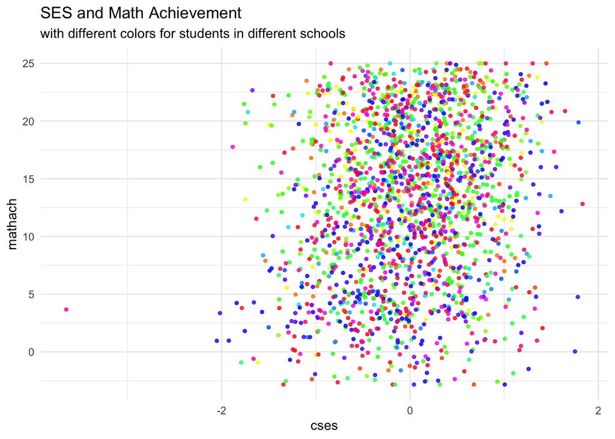

```r
schools <- sample(HSB$school, 50)

Sampledata <- HSB[is.element(HSB$school,schools), ]


ggplot(data = Sampledata, aes(x = cses, y = mathach, col = school)) +
  geom_point(size = 1, alpha = .8, position = "jitter") +
  theme_minimal() +
  theme(legend.position = "none") +
  scale_color_gradientn(colours = rainbow(50)) +
  labs(title    = "SES and Math Achievement",
       subtitle = "with different colors for students in different schools")
```

Ok that still looks a bit messy! But let’s add a least-squares regression line for each school. This is an OLS regression line using only the data for that school.

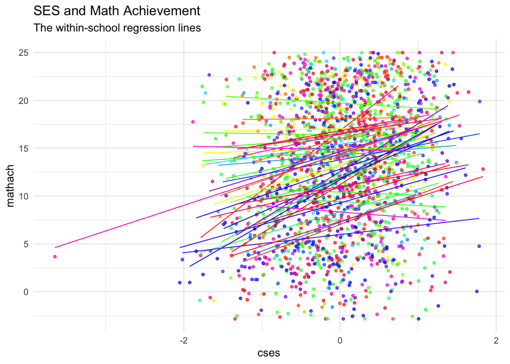

```r
ggplot(data = Sampledata, aes(x = cses, y = mathach, col = school, group = school)) +
  geom_point(size = 1, alpha = .7, position = "jitter") +
  theme_minimal() +
  theme(legend.position = "none") +
  scale_color_gradientn(colours = rainbow(50)) +
  geom_smooth(method = lm,
              se     = FALSE,
              size   = .4,
              alpha  = .7) + # to add regression line
  labs(title    = "SES and Math Achievement",
       subtitle = "The within-school regression lines")
```

We can see that most of the lines have positive slope, but there are a few that do not!

Using Model 3, we will do two things:

1. We will attempt to get overall average estimates these regression equations
- $\gamma_{00} =$ weighted average of $\beta_{0j}$ the school-level regression intercepts
- $\gamma_{10} =$ the weighted average of $\beta_{1j}$ the school-level slopes for the `cses` - `mathach` relationship
2. The variability across schools in $\beta_{0j}$ *and* $\beta_{1j}$
- Since our equations for the gammas include a random effect of each school, we can obtain variability estimates by working with these random effects $u_{0j}$ and $u_{1j}$

# Fitting Model 3, the Random Coefficients 2-level model

From the slides, we know that our combined equation for the hierarchical model with `cses` as level-1 predictor, `mathach` as outcome, and **both** random intercepts ($\beta_{0j}$) and slopes ($\beta_{1j}$) is:

$$Y_{ij} = \gamma_{00} + \gamma_{10}(cses) + u_{0j} + u_{1j}(cses) +
r_{ij}$$

So that means, our mixed-effects output should contain estimates of 2 fixed effects:

- $\gamma_{00}$, the weighted average intercept across schools (scaled to be the grand mean)
- $\gamma_{10}$, the weighted average `cses`-`mathach` slope across schools

Note that we do not estimate $\beta_{0j}$ or $\beta_{1j}$ directly, but they can be computed. Generally, that’s not our goal, but we could use these estimates for data in other analyses

We also should have estimates of the **variances** of 3 random effects

- $\text{Var}(u_{0j}) = \tau_{00}$
- $\text{Var}(u_{1j}) = \tau_{11}$
- $\text{Var}(r_{ij}) = \sigma^{2}$

AND we have a new term, a **covariance** between $u_{0j}$ and $u_{1j}$

- $\text{Cov}(u_{0j},u_{1j}) = \tau_{10}$

Let’s now estimate our mixed-effects parameters

```r
model3 <- lmer(mathach ~ cses + (cses|school), data = HSB)

summary(model3)
```

```
## Linear mixed model fit by REML ['lmerMod']
## Formula: mathach ~ cses + (cses | school)
##    Data: HSB
##
## REML criterion at convergence: 46714.2
##
## Scaled residuals:
##      Min       1Q   Median       3Q      Max
## -3.09680 -0.73193  0.01855  0.75386  2.89924
##
## Random effects:
##  Groups   Name        Variance Std.Dev. Corr
##  school   (Intercept)  8.681   2.9464
##           cses         0.694   0.8331   0.02
##  Residual             36.700   6.0581
## Number of obs: 7185, groups:  school, 160
##
## Fixed effects:
##             Estimate Std. Error t value
## (Intercept)  12.6362     0.2445   51.68
## cses          2.1932     0.1283   17.10
##
## Correlation of Fixed Effects:
##      (Intr)
## cses 0.009
```

Here’s a graph showing the difference between a hierarchical model and an OLS regression line.

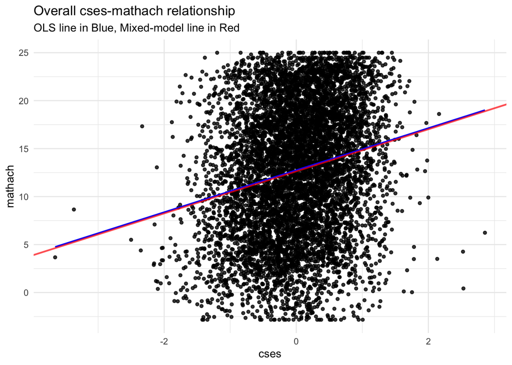

## Adding level 1 predictors with the random coefficients model

We can add as many level-1 predictors as we like. If we want to also model the level-1 slopes for these predictors as random, we need to change how our random-effects syntax looks. It is very similar to the combined equation though:

```r
mod3a <- lmer(mathach ~ cses + sex + (cses + sex | school), data =HSB)
```

Model equation:
$$Y_{ij} = \gamma_{00} + \gamma_{10}(cses) + \gamma_{20}(sex) + u_{0j} +
u_{1j}(cses) + u_{2j}(sex) + r_{ij}$$

Here’s our results. Note the new rows in the Random Effects part of the output

```
## Linear mixed model fit by REML ['lmerMod']
## Formula: mathach ~ cses + sex + (cses + sex | school)
##    Data: HSB
##
## REML criterion at convergence: 46662.2
##
## Scaled residuals:
##      Min       1Q   Median       3Q      Max
## -3.11109 -0.72851  0.03033  0.75386  2.88413
##
## Random effects:
##  Groups   Name        Variance Std.Dev. Corr
##  school   (Intercept)  7.9719  2.8235
##           cses         0.6161  0.7849   -0.02
##           sexMale      0.8632  0.9291    0.00  0.41
##  Residual             36.3543  6.0295
## Number of obs: 7185, groups:  school, 160
##
## Fixed effects:
##             Estimate Std. Error t value
## (Intercept)  12.0603     0.2495  48.330
## cses          2.1555     0.1260  17.109
## sexMale       1.1789     0.1865   6.321
##
## Correlation of Fixed Effects:
##         (Intr) cses
## cses     0.003
## sexMale -0.299  0.044
```

Not only do we have a new variance ($\text{Var}(u_{2j}) = \tau_{22}$), we have two new covariances, in fact, we have a 3 by 3 *variance-covariance matrix* $\textbf{T}$:

$$\begin{bmatrix}
\tau_{00} &. &. \\
\tau_{10} &\tau_{11} &. \\
\tau_{20} &\tau_{21} &\tau_{22}
\end{bmatrix}$$
The lower triangle (including the diagonal terms) are the only unique terms here. The diagonal lists the 3 random effect variances (of the random intercept, cses slope, and sex slopes in that order). The other entries are the covariances between those 3 terms. For example, $\tau_{10}$ is the covariance between the random effect $u_{0j}$ and $u_{1j}$

In the output from r, we only get this lower triangle including $\tau_{10}$, $\tau_{20}$, and $\tau_{21}$. The variances are given in the variance column, along with $\sigma^{2}$ which is the variance of the level-1 residuals ($r_{ij}$)

```
##  Groups   Name        Std.Dev. Corr
##  school   (Intercept) 2.82346
##           cses        0.78492  -0.020
##           sexMale     0.92911   0.004  0.406
##  Residual             6.02945
```

Finally, we can ask how much variance at level-1 we’ve reduced by adding sex as a level 1 predictor. We can use the CSES model as the comparison.

```r
(36.700 - 36.3543) / 36.700
```

```
## [1] 0.009419619
```

So despite the average slope for sex being significantly different from zero, we haven’t explained much more variance by adding it.

```r
mod3b <- lmer(mathach ~ cses + sex + minority + (cses | school), data =HSB)
summary(mod3b)
```

```
## Linear mixed model fit by REML ['lmerMod']
## Formula: mathach ~ cses + sex + minority + (cses | school)
##    Data: HSB
##
## REML criterion at convergence: 46457.7
##
## Scaled residuals:
##     Min      1Q  Median      3Q     Max
## -3.1812 -0.7197  0.0320  0.7600  2.8371
##
## Random effects:
##  Groups   Name        Variance Std.Dev. Corr
##  school   (Intercept)  6.318   2.5136
##           cses         0.495   0.7036   -0.17
##  Residual             35.672   5.9726
## Number of obs: 7185, groups:  school, 160
##
## Fixed effects:
##             Estimate Std. Error t value
## (Intercept)  12.9107     0.2330  55.414
## cses          1.8948     0.1229  15.421
## sexMale       1.2191     0.1644   7.417
## minorityYes  -3.1173     0.2104 -14.818
##
## Correlation of Fixed Effects:
##             (Intr) cses   sexMal
## cses        -0.086
## sexMale     -0.335 -0.045
## minorityYes -0.244  0.139 -0.012
```